# DanielaGarciaChavero_PEC2_AC

[figure not shown]

## Universitat Oberta de Catalunya

### Aprendizaje computacional - PAC 2

Grado en Informática 2025-2  
Estudios de Informática, Multimedia y Telecomunicación

### PAC 2: Redes neuronales - Aprendizaje supervizado

### Consideraciones generales

- Esta PAC debe realizarse de forma **estrictamente individual**. Cualquier indicio de copia será penalizado con un suspenso (D) para todas las partes implicadas, lo que puede afectar también a la calificación final de la asignatura.
- Es necesario indicar **todas las fuentes** utilizadas en la realización de la PAC. En caso contrario, se considerará plagio, lo que será penalizado con un suspenso (D) y puede implicar una evaluación negativa de la asignatura.

### Formato de la entrega

- La actividad puede realizarse en **Jupyter Notebook** o en **Google Colab**.
- La entrega debe incluir obligatoriamente:
  - El archivo en **formato HTML**, donde se visualicen el código, los resultados y los comentarios.
  - Un archivo **.zip** con el contenido completo de la actividad.
- **Se deben subir ambos archivos (HTML y ZIP) en la tarea correspondiente.**
- Dentro del archivo **.zip** se debe incluir:
  - El **notebook** utilizado.
  - Los **ficheros necesarios** para la correcta ejecución de la actividad (por ejemplo: datasets, imágenes, gráficos generados, etc.).
- La exportación a HTML puede realizarse desde el menú *File >> Download as >> HTML* en Jupyter Notebook o desde *File >> Download >> HTML* en Google Colab.
- Se recomienda verificar que el HTML se visualiza correctamente antes de realizar la entrega.

### Información de la práctica

Esta actividad se basa en el contenido del **tema 4.6 del Módulo 1 (Redes neuronales)** y corresponde a los contenidos trabajados en la asignatura hasta la **semana 10**. Las **redes neuronales** son modelos de aprendizaje supervisado inspirados en el funcionamiento general de las neuronas biológicas, que permiten aprender relaciones entre los datos de entrada y las salidas esperadas mediante un proceso iterativo de ajuste de pesos. En esta actividad se trabajará con los conceptos básicos de una red neuronal, incluyendo su estructura, el paso hacia delante (*forward propagation*), la función de pérdida y el proceso de entrenamiento, así como el análisis de distintos elementos del modelo, como el número de capas, el número de neuronas, las funciones de activación y algunos hiperparámetros. Finalmente, se construirá y evaluará una **red neuronal** para resolver un problema de clasificación, interpretando los resultados obtenidos y comparando el comportamiento del modelo bajo diferentes configuraciones.

### Ponderación

| Ejercicio | Apartado | Puntos |
| --- | --- | --- |
| **Ejercicio 1** | a | 1 |
|  | b | 1 |
|  | c | 1 |
| **Ejercicio 2** | a | 2 |
|  | b | 2 |
| **Ejercicio 3** | a | 0.5 |
|  | b | 1.5 |
|  | c | 1 |
| Total |  | 10 |

### Fecha de entrega

**11 de mayo de 2026**

**Nombre y apellidos:** Daniela García Chavero

## Índice de contenidos

Esta PEC está estructurada en cuatro bloques principales. Te recomendamos seguir el orden establecido, ya que la primera sección es necesaria para poder resolver los ejercicios posteriores.

- **1. Aprendizaje sobre la Red Neuronal** *Guía práctica paso a paso.* Esta sección no requiere que programes nada, pero es importante que leas y ejecutes el código. Te enseñará cómo preparar los datos (dataset Iris), cómo se define la arquitectura de un Perceptrón Multicapa (MLP) desde cero, cómo se entrena (Forward y Backpropagation) y cómo se evalúan los resultados.
- **2. Ejercicio 1 - Conocimiento de redes neuronales (3 pts.)** *Evaluación teórica.* Tendrás que responder preguntas teóricas para demostrar que has entendido los conceptos de la Sección 1. (Se responde en formato texto o Markdown).
- **3. Ejercicio 2 - Clasificación de vinos con MLP (4 pts.)** *Evaluación práctica (Programación).* Aquí pondrás a prueba tus conocimientos de código. Tendrás que implementar un MLP para clasificar un nuevo conjunto de datos (dataset Wine), siguiendo todos los pasos aprendidos: preprocesamiento, definición de la red, entrenamiento y evaluación utilizando una métrica personalizada.
- **4. Ejercicio 3 - Interpretación de resultados (3 pts.)** *Cálculo manual y razonamiento.* En este último ejercicio analizarás el comportamiento de un modelo clínico a partir de una matriz de confusión. Calcularás a mano métricas, interpretando qué significan estos errores en la vida real. También calcularás el paso a paso del resultado de una neurona individual.

# 1. Aprendizaje sobre la Red neuronal

## 1.1. Importaciones necesarias

**Algunas consideraciones antes de iniciar con la PAC:**

1. Esta PAC está desarrollada utilizando **Python** y librerías como `pandas`, `numpy` y `scikit-learn`. Las implementaciones del modelo MLP se basan en estas herramientas.
2. Al ejecutar el notebook pueden aparecer mensajes informativos relacionados con las librerías utilizadas. **No son errores**, sino avisos propios del entorno. **Puedes ignorarlos**, ya que no afectan al funcionamiento del código.
3. Si deseas reducir la cantidad de mensajes técnicos mostrados en pantalla, puedes aplicar configuraciones que limiten los avisos a mensajes más relevantes. Aun así, algunos mensajes pueden seguir apareciendo y **no influyen en la práctica**.
4. El notebook utiliza librerías como `pandas`, `numpy`, `matplotlib` y `scikit-learn` para la carga de datos, preprocesamiento, entrenamiento y visualización. Entornos como Google Colab ya incluyen estas librerías, por lo que **no necesitas instalar nada adicional**.
5. La **sección 1** de este notebook actúa como una **guía de aprendizaje** complementaria al material del módulo. El código de esta sección está **completamente implementado**: ejecútalo en orden, léelo con atención y asegúrate de entender el funcionamiento de cada bloque antes de comenzar los ejercicios. Comprender esta sección es **necesario** para poder responder correctamente la PAC correspondiente a las secciones 2,3,4.

```python
import pandas as pd  # Manejo de datos en tablas (DataFrame)
import numpy as np  # Cálculos numéricos y arrays
import matplotlib.pyplot as plt  # Gráficos y visualización

from sklearn.metrics import confusion_matrix, ConfusionMatrixDisplay  # Matriz de confusión
from sklearn.model_selection import train_test_split  # Separar datos en train y test
from sklearn.preprocessing import OneHotEncoder, LabelEncoder  # Convertir etiquetas a formato numérico
```

## 1.2. Definición del conjunto de datos

Una empresa dedicada al sector floral y ornamental desea automatizar la clasificación de plantas del conjunto **Iris**. Este conjunto de datos es uno de los más conocidos en problemas de clasificación supervisada y resulta adecuado para entrenar un modelo de tipo **multilayer perceptron (MLP)**. El dataset contiene información de **3 especies de flores Iris**:

- **Iris setosa**
- **Iris virginica**
- **Iris versicolor**

Para cada especie se dispone de **50 muestras**, por lo que el conjunto completo está formado por **150 observaciones**. En cada muestra se han medido **4 características numéricas** que describen dimensiones del sépalo y del pétalo:

- `sepal length`: longitud del sépalo
- `sepal width`: anchura del sépalo
- `petal length`: longitud del pétalo
- `petal width`: anchura del pétalo

El objetivo de esta práctica es construir un modelo de clasificación automática capaz de predecir a qué especie pertenece cada flor a partir de estas cuatro variables de entrada. El modelo deberá distinguir entre las clases: **Iris setosa**, **Iris virginica** y **Iris versicolor**. Para ello, utilizaremos un **multilayer perceptron (MLP)**, es decir, una red neuronal multicapa diseñada para aprender relaciones no lineales entre las variables de entrada y la clase de salida.

Antes de entrenar el modelo, será necesario preparar correctamente los datos. Esto incluye separar las variables predictoras y la variable objetivo, dividir el conjunto de datos en entrenamiento y prueba, y transformar las etiquetas de salida si el modelo lo requiere.

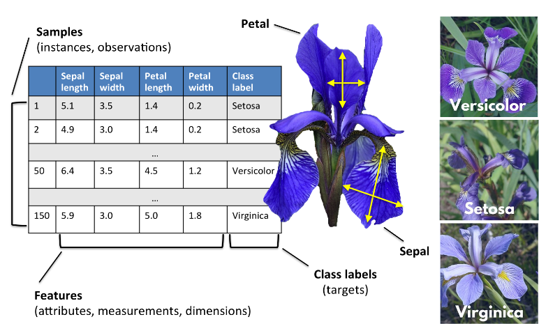

## 1.3. Carga del dataset Iris

El dataset contiene 150 muestras con 4 características de entrada y una columna de etiqueta de clase.

```python
import pandas as pd

url = "https://raw.githubusercontent.com/mwaskom/seaborn-data/master/iris.csv"

df = pd.read_csv(url)

# Renombrar la columna
df = df.rename(columns={"species": "labels"})

print(f"Forma del dataset: {df.shape}")
print(f"\nDistribución de clases:\n{df.labels.value_counts()}")
df.head()
```

```
Forma del dataset: (150, 5)

Distribución de clases:
labels
setosa        50
versicolor    50
virginica     50
Name: count, dtype: int64
```

|  | sepal_length | sepal_width | petal_length | petal_width | labels |
| --- | --- | --- | --- | --- | --- |
| 0 | 5.1 | 3.5 | 1.4 | 0.2 | setosa |
| 1 | 4.9 | 3.0 | 1.4 | 0.2 | setosa |
| 2 | 4.7 | 3.2 | 1.3 | 0.2 | setosa |
| 3 | 4.6 | 3.1 | 1.5 | 0.2 | setosa |
| 4 | 5.0 | 3.6 | 1.4 | 0.2 | setosa |

## 1.4. División en conjuntos de entrenamiento, validación y test

Separamos las columnas del dataset en dos variables:

- **`X`**: matriz de entrada, contiene las 4 características medidas de cada flor (longitud y anchura del sépalo y del pétalo). Tiene forma (150 filas, 4 columnas).
- **`y`**: vector de salida, contiene la etiqueta de clase de cada muestra (`Iris-setosa`, `Iris-versicolor` o `Iris-virginica`). Tiene longitud `150`.

A continuación dividimos los datos en tres subconjuntos:

- **Entrenamiento (64%)**: para ajustar los pesos del modelo.
- **Validación (16%)**: para supervisar el aprendizaje y detectar sobreajuste.
- **Test (20%)**: para evaluar el rendimiento final sobre datos no vistos.

```python
X = df.iloc[:, :-1].values
y = df.iloc[:, -1].values

# Primera división: separar el 20% como test
X_temp, X_test, y_temp, y_test = train_test_split(X, y, test_size=0.2, random_state=0)

# Segunda división: del 80% restante, 20% para validación
X_train, X_val, y_train, y_val = train_test_split(X_temp, y_temp, test_size=0.2, random_state=0)

print(f"Entrenamiento : {len(X_train)} muestras")
print(f"Validación    : {len(X_val)} muestras")
print(f"Test          : {len(X_test)} muestras")
```

```
Entrenamiento : 96 muestras
Validación    : 24 muestras
Test          : 30 muestras
```

## 1.5. Normalización de los datos

Normalizamos las características para que tengan media 0 y desviación estándar 1. La normalización ayuda al modelo a converger más rápido durante el entrenamiento, ya que evita que características con valores muy grandes dominen sobre las demás. La fórmula general de normalización es:

$$x_{\text{normalizado}} = \frac{x - \mu_{\text{train}}}{\sigma_{\text{train}}}$$

donde $\mu_{\text{train}}$ es la media y $\sigma_{\text{train}}$ es la desviación estándar calculadas **únicamente sobre el conjunto de entrenamiento**. Aplicada al conjunto de entrenamiento, la fórmula queda:

$$X_{\mathrm{train\_norm}} = \frac{X_{\mathrm{train}} - \mu_{\mathrm{train}}}{\sigma_{\mathrm{train}}}$$

El motivo de calcular $\mu$ y $\sigma$ solo con los datos de entrenamiento es evitar la **fuga de información** (*data leakage*): si usáramos también los datos de validación o test para calcular estos estadísticos, el modelo estaría indirectamente "viendo" información de datos que se supone que no conoce, lo que daría una evaluación artificialmente optimista. Los mismos valores de $\mu_{\text{train}}$ y $\sigma_{\text{train}}$ se aplican después a validación y test para mantener la coherencia.

```python
mu = np.mean(X_train, axis=0)
sigma = np.std(X_train, axis=0)
```

```python
X_train_n = (X_train - mu) / sigma
X_val_n = (X_val - mu) / sigma
X_test_n = (X_test - mu) / sigma

print(f"Media por característica : {mu}")
print(f"Desv. estándar : {sigma}")
```

```
Media por característica : [5.87291667 3.028125   3.79583333 1.21979167]
Desv. estándar : [0.84255059 0.44269608 1.76434104 0.76982409]
```

## 1.6 Codificación one-hot de las etiquetas

La columna `label` del dataset Iris contiene cadenas de texto (`'Iris-setosa'`, `'Iris-versicolor'`, `'Iris-virginica'`). Como se indica en el módulo 1, las redes neuronales trabajan con algoritmos matemáticos por lo que el MLP no puede trabajar directamente con texto. Necesitamos convertirlas a un formato numérico. Una opción sería asignar un número a cada clase (0, 1, 2), pero esto introduciría un orden artificial entre las clases que no existe en realidad: el modelo podría interpretar que `Iris-virginica` (2) es "mayor" o "más cercana" a `Iris-versicolor` (1) que a `Iris-setosa` (0), lo cual no tiene ningún sentido biológico.

La solución es la **codificación one-hot**: cada clase se representa como un vector binario de longitud igual al número de clases, donde solo la posición correspondiente a esa clase vale 1 y el resto valen 0:

$$\text{Iris-setosa} = \begin{pmatrix}1\\0\\0\end{pmatrix} \quad \text{Iris-versicolor} = \begin{pmatrix}0\\1\\0\end{pmatrix} \quad \text{Iris-virginica} = \begin{pmatrix}0\\0\\1\end{pmatrix}$$

Esta representación es importante porque la capa de salida del MLP también produce un vector de 3 valores (uno por clase), y durante el entrenamiento necesitamos comparar esa salida con la etiqueta real. Con la codificación one-hot, esa comparación es directa: el modelo aprende a que la neurona de salida correcta se acerque a 1 y las demás se acerquen a 0.

El codificador se ajusta **únicamente con las etiquetas de entrenamiento** y después se aplica a validación y test, por el mismo motivo que con la normalización: evitar cualquier fuga de información.

```python
encoder = OneHotEncoder(sparse_output=False)
encoder.fit(y_train.reshape(-1, 1))

y_train_oh = encoder.transform(y_train.reshape(-1, 1)) # oh = One-Hot
y_val_oh = encoder.transform(y_val.reshape(-1, 1))
y_test_oh = encoder.transform(y_test.reshape(-1, 1))

print(f"Forma de y_train_oh: {y_train_oh.shape}  -> ({len(y_train)} muestras, 3 clases)")
print(f"\nAsí se ven las primeras 5 etiquetas del dataset codificadas:\n{y_train_oh[:5]}")
```

```
Forma de y_train_oh: (96, 3)  -> (96 muestras, 3 clases)

Así se ven las primeras 5 etiquetas del dataset codificadas:
[[0. 1. 0.]
 [1. 0. 0.]
 [0. 0. 1.]
 [1. 0. 0.]
 [0. 0. 1.]]
```

## 1.7. Funciones de activación

En el tema 4 del Módulo 1 se introduce el concepto de aprendizaje supervisado y se mencionan las funciones de activación como parte necesaria de las redes neuronales. Aquí las retomamos y las situamos en contexto.

Pensemos primero en una sola neurona. Recibe varias entradas, las combina linealmente (las multiplica por sus pesos y las suma) y obtiene un valor $z$. El problema es que una combinación lineal de entradas solo puede representar relaciones lineales. La **función de activación** $\phi(z)$ se aplica sobre ese valor $z$ para introducir no linealidad, permitiendo que la red aprenda patrones más complejos:

$$\text{salida} = \phi\left(\sum_i w_i x_i\right)$$

En un MLP esta idea se repite en cada capa: cada neurona calcula su combinación lineal y aplica una función de activación. Gracias a esto, al apilar varias capas, la red puede aproximar funciones arbitrariamente complejas. Sin funciones de activación, no importaría cuántas capas tuviéramos: el resultado seguiría siendo equivalente a una única transformación lineal.

Las funciones que usaremos en este notebook son las siguientes:

```python
def sigmoid(z):
    """Función logística: comprime la entrada al intervalo (0, 1)."""
    return 1 / (1 + np.exp(-z))

def relu(z):
    """ReLU: devuelve 0 para valores negativos, el propio valor para positivos."""
    return np.maximum(0, z)

def tanh(z):
    """Tangente hiperbólica: comprime la entrada al intervalo (-1, 1)."""
    return np.tanh(z)

def softmax(z):
    """Softmax: convierte un vector de logits en una distribución de probabilidad."""
    exp_z = np.exp(z - np.max(z, axis=1, keepdims=True))  # estabilidad numérica
    return exp_z / np.sum(exp_z, axis=1, keepdims=True)
```

## 1.8. Definición de la arquitectura y parámetros del MLP

Un **MLP** es una red neuronal formada por varias capas de neuronas conectadas entre sí. La información entra por la primera capa, se transforma progresivamente a través de las capas ocultas y produce una predicción en la capa de salida.

En nuestro caso, el dataset Iris nos da 4 características de entrada que no podemos modificar, son los datos que nos proporciona la naturaleza. Lo que sí podemos manipular son los **pesos** $W$: cada entrada se multiplica por un peso antes de pasar a la siguiente capa. El objetivo del entrenamiento es precisamente encontrar los valores de esos pesos que hagan que la salida del modelo se parezca lo máximo posible a la etiqueta real $y$. Dicho de forma simple: el modelo aprende ajustando $W$ hasta que, dado un vector de entrada $X$, la salida $\hat{y}$ coincida con la clase correcta.

Las funciones de activación `sigmoid` en las capas ocultas introducen la no linealidad necesaria para que el modelo pueda separar las tres clases de flores, que no son linealmente separables en su totalidad. En la capa de salida usamos `softmax` porque queremos obtener una probabilidad para cada una de las 3 clases, y softmax garantiza que esas tres probabilidades sumen exactamente 1.

Los pesos se inicializan de forma aleatoria en el intervalo $[-0.1, 0.1]$ para romper la simetría: si todos los pesos empezaran con el mismo valor, todas las neuronas aprenderían exactamente lo mismo y la red no tendría capacidad real de representación.

La arquitectura que construimos es:

```
Entrada (4) → Capa oculta 1 (16 neuronas, sigmoid) → Capa oculta 2 (8 neuronas, sigmoid) → Salida (3, softmax)
```

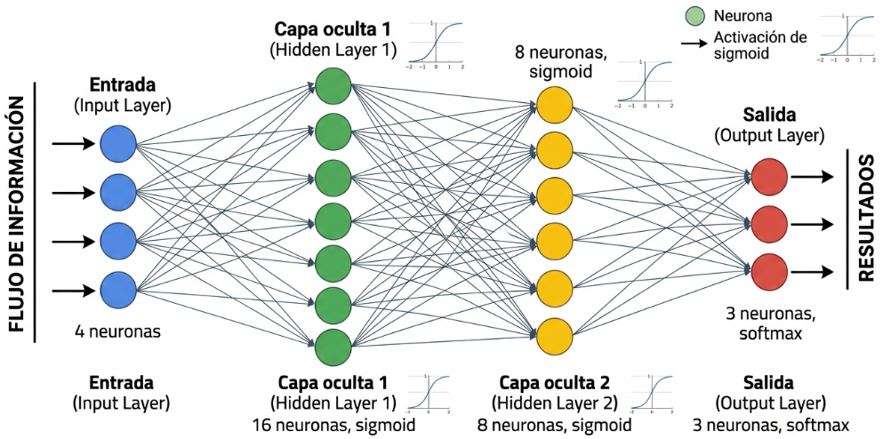

```python
# Dimensiones de cada capa
n_input   = 4                     # 4 características. Las 4 columnas de información
n_hidden1 = 16                    # neuronas en la primera capa oculta
n_hidden2 = 8                     # neuronas en la segunda capa oculta
n_output  = 3                     # 3 clases

print(f"Arquitectura: {n_input} -> {n_hidden1} -> {n_hidden2} -> {n_output}")
```

```
Arquitectura: 4 -> 16 -> 8 -> 3
```

```python
np.random.seed(42)

# Matrices de pesos e inicialización aleatoria
W1 = np.random.uniform(-0.1, 0.1, size=(n_input, n_hidden1))  # Pesos aleatorios de entrada 4  y salida 16 (4, 16)
W2 = np.random.uniform(-0.1, 0.1, size=(n_hidden1, n_hidden2))  # (16, 8)
W3 = np.random.uniform(-0.1, 0.1, size=(n_hidden2, n_output))   # (8, 3)

print(f"\nForma de W1: {W1.shape}")
print(f"Forma de W2: {W2.shape}")
print(f"Forma de W3: {W3.shape}")
```

```
Forma de W1: (4, 16)
Forma de W2: (16, 8)
Forma de W3: (8, 3)
```

## 1.9. Entrenamiento: forward propagation y backpropagation

El entrenamiento de un MLP se basa en repetir el siguiente ciclo durante un número de épocas determinado. Una **época** es una pasada completa por todos los datos de entrenamiento.

1. **Forward pass**: la entrada $X$ se propaga hacia adelante capa por capa. En cada capa se calcula la combinación lineal con los pesos y se aplica la función de activación. El resultado final es la predicción $\hat{y}$ del modelo.
2. **Función de pérdida**: comparamos la predicción $\hat{y}$ con la etiqueta real $y$ mediante la **entropía cruzada categórica**. Esta función mide cuánto se equivoca el modelo: cuanto mayor es el error, mayor es la pérdida. El objetivo del entrenamiento es minimizar este valor.
3. **Backpropagation**: una vez calculada la pérdida, propagamos el error hacia atrás a través de la red aplicando la regla de la cadena. Esto nos permite saber en qué medida ha contribuido cada peso al error total, es decir, calculamos el **gradiente** de la pérdida respecto a cada peso.
4. **Actualización de pesos**: ajustamos cada peso en la dirección opuesta al gradiente, con un paso controlado por la **tasa de aprendizaje** (*learning rate*) $\eta$:

$$W \leftarrow W - \eta \cdot \frac{\partial J}{\partial W}$$

Este proceso se repite época tras época. Con cada iteración los pesos se van ajustando y la pérdida debería ir disminuyendo progresivamente, señal de que el modelo está aprendiendo a relacionar las entradas con las clases correctas. Pueden consultar más información sobre el tema en el apartado 4.6 del módulo 1 de la asignatura.

```python
learning_rate = 0.01
epochs        = 300
loss_history  = []

for epoch in range(epochs):

    # ── FORWARD PROPAGATION ──────────────────────────────────────────────────
    # Capa oculta 1
    z1 = np.dot(X_train_n, W1)     # combinación lineal: (n_muestras, 16)
    a1 = sigmoid(z1)               # activación: (n_muestras, 16)

    # Capa oculta 2
    z2 = np.dot(a1, W2)            # combinación lineal: (n_muestras, 8)
    a2 = sigmoid(z2)               # activación: (n_muestras, 8)

    # Capa de salida
    z3 = np.dot(a2, W3)            # combinación lineal: (n_muestras, 3)
    a3 = softmax(z3)               # probabilidades de clase: (n_muestras, 3)

    # ── FUNCIÓN DE PÉRDIDA (entropía cruzada categórica) ─────────────────────
    loss = -np.sum(y_train_oh * np.log(a3 + 1e-9))
    loss_history.append(loss)

    # ── BACKPROPAGATION ───────────────────────────────────────────────────────
    # Error en la capa de salida
    delta3 = a3 - y_train_oh                                    # (n_muestras, 3)

    # Error en la capa oculta 2
    delta2 = np.dot(delta3, W3.T) * a2 * (1 - a2)              # (n_muestras, 8)

    # Error en la capa oculta 1
    delta1 = np.dot(delta2, W2.T) * a1 * (1 - a1)              # (n_muestras, 16)

    # ── ACTUALIZACIÓN DE PESOS ────────────────────────────────────────────────
    W3 -= learning_rate * np.dot(a2.T, delta3)
    W2 -= learning_rate * np.dot(a1.T, delta2)
    W1 -= learning_rate * np.dot(X_train_n.T, delta1)
```

Al finalizar el entrenamiento representamos la evolución de la pérdida a lo largo de las épocas. Una curva que desciende de forma suave indica que el modelo está aprendiendo correctamente. También imprimimos el valor de la pérdida al inicio y al final para verificar que el entrenamiento ha reducido el error.

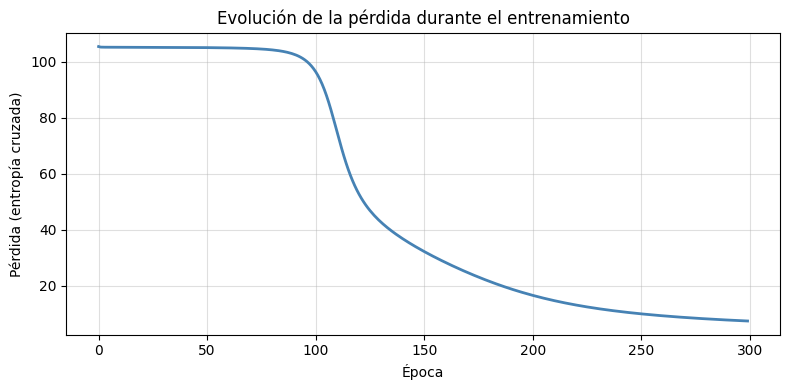

```
Pérdida inicial: 105.4869
Pérdida final  : 7.4159
```

```python
# Curva de pérdida
plt.figure(figsize=(8, 4))
plt.plot(loss_history, color='steelblue', linewidth=2)
plt.title('Evolución de la pérdida durante el entrenamiento')
plt.xlabel('Época')
plt.ylabel('Pérdida (entropía cruzada)')
plt.grid(True, alpha=0.4)
plt.tight_layout()
plt.show()

print(f"Pérdida inicial: {loss_history[0]:.4f}")
print(f"Pérdida final  : {loss_history[-1]:.4f}")
```

## 1.10. Evaluación del modelo

Una vez entrenado el modelo, necesitamos medir qué tan bien generaliza sobre datos que no ha visto durante el entrenamiento. Para ello usamos dos conjuntos:

- **Validación**: permite detectar problemas durante el entrenamiento, como el sobreajuste. Si la pérdida en entrenamiento baja pero el accuracy en validación no mejora, es una señal de que el modelo está memorizando los datos en lugar de aprender patrones generales. En este notebook no hemos usado la validación para tomar decisiones (como parar el entrenamiento antes o ajustar hiperparámetros), pero en un proyecto real sería el conjunto que guiaría esas decisiones.
- **Test**: es la evaluación final e imparcial del modelo. Solo se usa una vez, al final, para obtener una estimación honesta del rendimiento sobre datos completamente nuevos.

La métrica que usamos es el **accuracy** (exactitud), que mide la proporción de muestras clasificadas correctamente:

$$\text{accuracy}(y, \hat{y}) = \frac{1}{n}\sum_{i=1}^{n} \mathbf{1}[y_i = \hat{y}_i]$$

donde $n$ es el número de muestras, $y_i$ es la etiqueta real y $\hat{y}_i$ es la clase predicha por el modelo.

```python
def predict(X, W1, W2, W3):
    """Forward pass completo: devuelve la clase predicha para cada muestra."""
    a1 = sigmoid(np.dot(X,  W1))
    a2 = sigmoid(np.dot(a1, W2))
    a3 = softmax(np.dot(a2, W3))
    return np.argmax(a3, axis=1)

def accuracy(y_true, y_pred):
    return np.mean(y_true == y_pred)
```

```python
y_val_idx  = np.argmax(y_val_oh,  axis=1)
y_test_idx = np.argmax(y_test_oh, axis=1)

acc_val  = accuracy(y_val_idx,  predict(X_val_n,  W1, W2, W3))
acc_test = accuracy(y_test_idx, predict(X_test_n, W1, W2, W3))

print(f"Accuracy en validación : {acc_val:.4f}")
print(f"Accuracy en test       : {acc_test:.4f}")
```

```
Accuracy en validación : 0.9167
Accuracy en test       : 1.0000
```

Además del accuracy, visualizamos la **matriz de confusión**, que muestra de forma detallada cuántas muestras de cada clase fueron clasificadas correctamente y cuántas fueron confundidas con otra clase. Cada fila representa la clase real y cada columna la clase predicha: los valores en la diagonal son aciertos, y los valores fuera de la diagonal son errores.

Para entender la matriz de confusión es útil conocer los cuatro conceptos básicos que la componen (definidos aquí para una clase concreta frente al resto):

- **TP (True Positive)**: el modelo predice que la muestra pertenece a una clase y tiene razón.
- **TN (True Negative)**: el modelo predice que la muestra *no* pertenece a una clase y tiene razón.
- **FP (False Positive)**: el modelo predice que la muestra pertenece a una clase pero se equivoca.
- **FN (False Negative)**: el modelo predice que la muestra *no* pertenece a una clase pero se equivoca.

En un problema multiclase como Iris, estos valores se calculan de forma independiente para cada clase considerando las demás como negativas. Los valores en la diagonal de la matriz corresponden a los **TP** de cada clase, mientras que los valores fuera de la diagonal representan los **FP** y **FN** según la fila y columna en que aparezcan. El código a continuación, se aplica en el conjunto `test` ya que este conjunto se considera una prueba independiente.

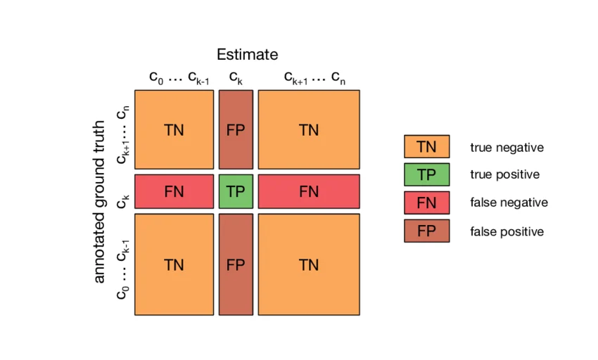

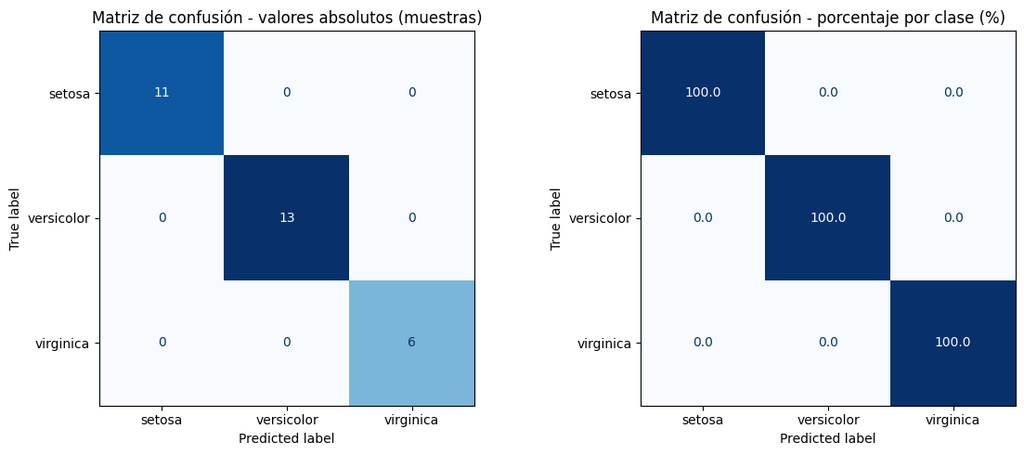

```python
y_test_pred = predict(X_test_n, W1, W2, W3)
cm = confusion_matrix(y_test_idx, y_test_pred)
cm_norm = confusion_matrix(y_test_idx, y_test_pred, normalize='true')

fig, axes = plt.subplots(1, 2, figsize=(12, 5))

# Matriz de confusión con valores absolutos
ConfusionMatrixDisplay(confusion_matrix=cm,
                       display_labels=encoder.categories_[0]).plot(
    ax=axes[0], colorbar=False, cmap='Blues')
axes[0].set_title('Matriz de confusión - valores absolutos (muestras)')

# Matriz de confusión normalizada (porcentajes)
cm_percent = cm_norm * 100
ConfusionMatrixDisplay(confusion_matrix=cm_percent,
                       display_labels=encoder.categories_[0]).plot(
    ax=axes[1], colorbar=False, cmap='Blues', values_format='.1f')

axes[1].set_title('Matriz de confusión - porcentaje por clase (%)')

plt.tight_layout()
plt.show()
```

Interpretación de la matriz de confusión en el conjunto test

- **True Positives (TP):** los valores en la diagonal muestran cuántas muestras de cada clase fueron clasificadas correctamente. En nuestro caso, el modelo acierta en todas las muestras de las tres clases, lo que se traduce en una diagonal perfecta.
- **False Positives (FP):** no hay ningún caso en que el modelo haya asignado incorrectamente una muestra a una clase que no le corresponde. Todas las predicciones positivas son correctas.
- **False Negatives (FN):** ninguna muestra ha sido clasificada como una clase distinta a la suya. El modelo no ha "perdido" ninguna muestra de ninguna clase.
- **True Negatives (TN):** todas las combinaciones fuera de la diagonal son cero, lo que confirma que no existe ninguna confusión entre clases.

La matriz normalizada confirma este resultado: el 100% de las muestras de cada clase han sido clasificadas correctamente. Esto indica que, con esta configuración de pesos, tasa de aprendizaje y número de épocas, el MLP ha aprendido a separar perfectamente las tres especies de Iris en el conjunto de test. No obstante, conviene recordar que el dataset Iris es un dataset clásico de aprendizaje, ampliamente utilizado en la literatura como ejemplo introductorio precisamente porque sus clases son bastante separables y el número de características es reducido. Por ello, obtener un resultado perfecto o cercano al 100% es un comportamiento esperado y habitual con modelos bien configurados. En problemas reales, con datos más ruidosos, clases solapadas o un mayor número de características, los resultados serían notablemente más bajos y la matriz de confusión mostraría errores que habría que analizar y corregir.

## Fin del código base

Todo lo que has visto hasta este punto: la carga del dataset, el preprocesado, la arquitectura del MLP, el entrenamiento con **forward propagation** y **backpropagation**, y la evaluación con **accuracy** y **matriz de confusión**, forma parte del **material adicional de aprendizaje inicial** proporcionado para que puedas familiarizarte con los conceptos y la estructura de un perceptrón multicapa antes de empezar la actividad.

A partir de aquí comienza la **PAC 2**. Lee con atención los enunciados, razona tus respuestas y recuerda indicar todas las fuentes que utilices.

# 2. Ejercicio 1 - Conocimiento de redes neuronales

**Ejercicio 1 [3 pts.]**

A partir de los conceptos trabajados en el módulo, responde de forma razonada a los apartados **a**, **b** y **c**.  
En este ejercicio, la respuesta debe realizarse **a mano**, explicando el procedimiento y el razonamiento seguido.  
**No se debe implementar ningún código**.

**a) El rol de los pesos y qué aprende el modelo [1 pt.]**

En el código base se definen tres matrices de pesos: `W1`, `W2` y `W3`.  
El dataset Iris proporciona 4 variables de entrada. Explica de forma razonada qué representan los pesos en la red y qué significa que el modelo "aprende".  
En tu respuesta, incluye qué ocurre con los pesos durante el entrenamiento, cómo afectan a la transformación de los datos entre capas y qué pasaría si todos los pesos se inicializaran a 0.

**a)** En una red neuronal, los **pesos** `W1`, `W2` y `W3` representan la **fuerza de las conexiones** entre las neuronas de capas consecutivas. Como el dataset **Iris** tiene **4 variables de entrada**, la matriz `W1` pondera la influencia de cada variable sobre las neuronas de la primera capa oculta. Las matrices `W2` y `W3` transforman las representaciones internas hasta producir la salida del modelo.

Decir que el modelo **"aprende"** significa que ajusta sus **pesos y sesgos** durante el entrenamiento para reducir el error entre sus predicciones y las clases reales. En la **propagación hacia adelante**, los datos se multiplican por las matrices de pesos, se combinan con sesgos y pasan por funciones de activación, generando representaciones cada vez más útiles para separar las clases de Iris. En la **retropropagación**, se calcula el gradiente del error respecto a cada peso y estos se actualizan, normalmente mediante **descenso del gradiente**.

Si todos los pesos se inicializaran en **0**, todas las neuronas de una misma capa producirían la **misma salida** y recibirían los **mismos gradientes**. Esto impediría **romper la simetría**, es decir, las neuronas aprenderían lo mismo y la red perdería capacidad para capturar patrones distintos. Por eso, los pesos suelen inicializarse con **valores pequeños y aleatorios**.

**b) Funciones de activación: sigmoid vs softmax [1 pt.]**

Explica con tus propias palabras la diferencia entre `sigmoid` y `softmax`. Describe qué tipo de salida genera cada una, en qué rango de valores se mueven y cómo se interpretan. Justifica por qué `sigmoid` se utiliza en las capas ocultas mientras que `softmax` se utiliza en la capa de salida en un problema de clasificación multiclase como Iris.

**b)** La función **`sigmoid`** transforma cada valor de entrada en un número entre **0 y 1** y actúa de forma **independiente** sobre cada neurona. Por eso, es útil en las **capas ocultas**, donde permite introducir **no linealidad** y generar activaciones internas que ayudan a la red a aprender patrones más complejos.

La función **`softmax`** también produce valores entre **0 y 1**, pero se aplica sobre todo el **vector de salida**. Su principal característica es que hace que la suma de todas las salidas sea **1**, por lo que sus valores pueden interpretarse como una **distribución de probabilidades** entre clases.

En el dataset **Iris**, el objetivo es clasificar cada flor en una sola de tres especies (**Setosa**, **Versicolor** o **Virginica**). Como las clases son **mutuamente excluyentes**, se usa **softmax** en la capa de salida para comparar las probabilidades de las tres clases y elegir la más alta.

Resumiendo, **`sigmoid`** se usa en las capas ocultas para transformar los datos y aportar no linealidad, mientras que **`softmax`** se usa en la salida para obtener probabilidades normalizadas en un problema de **clasificación multiclase**.

**c) Partición de los datos [1 pt.]**

En el código base se ha utilizado una partición específica del dataset Iris: 64% entrenamiento, 16% validación y 20% test. Sin embargo, en la literatura existen otras particiones habituales para dividir los datos en conjuntos de entrenamiento, validación y test. Investiga y describe las **2 particiones más comunes** que se utilizan en la literatura. Para cada una indica:

- Qué porcentaje se asigna a cada conjunto.
- Qué justificación estadística tiene esa distribución, es decir, qué se busca garantizar con esa proporción de datos en entrenamiento y en test.

**c)** La **partición de los datos** consiste en dividir el conjunto original en subconjuntos con funciones distintas: **entrenamiento**, **validación** y **test**. Esta separación permite entrenar el modelo, ajustar sus hiperparámetros y evaluar su capacidad de generalización con datos no vistos.

Una partición habitual es **70% / 15% / 15%**. El **70% de entrenamiento** se utiliza para que el modelo aprenda los pesos a partir de los datos. El **15% de validación** sirve para comparar configuraciones del modelo, ajustar hiperparámetros y detectar posibles problemas de sobreajuste. El **15% de test** se reserva hasta el final para obtener una evaluación objetiva del rendimiento.

Otra partición frecuente es **80% / 10% / 10%**, especialmente cuando se dispone de suficientes datos o se desea dar más ejemplos al entrenamiento. En este caso, el modelo cuenta con más información para aprender, mientras que validación y test siguen teniendo un tamaño suficiente para evaluar el desempeño.

En el caso del dataset **Iris**, al ser un conjunto pequeño, es importante que la división sea **estratificada**, es decir, que mantenga proporciones similares de las tres clases en entrenamiento, validación y test. Esto evita que alguna especie quede poco representada y permite una evaluación más fiable del modelo.

# 3. Ejercicio 2 - Clasificación de vinos con MLP

**Ejercicio 2 [4 pts.]**

En este ejercicio construirás un clasificador MLP para el dataset **Wine** siguiendo la misma metodología que se ha mostrado en el código base con el dataset Iris. Se proporcionan la carga del dataset y algunas celdas de apoyo. Tu tarea es completar los pasos indicados e implementar el modelo.

A partir de los conceptos anteriores, responde de forma razonada a los apartados **a** y **b**. En este ejercicio, la respuesta debe realizarse **programando, utilizando código**.

Una bodega artesanal desea automatizar la clasificación de sus variedades de vino. El dataset **Wine** es un conjunto de clasificación supervisada que contiene análisis químicos de vinos producidos en Italia a partir de **3 variedades de uva distintas**. El objetivo es construir un modelo capaz de predecir la variedad a partir de sus características químicas.

El dataset contiene **178 muestras** distribuidas en 3 clases:

- **Clase 1**: 59 muestras
- **Clase 2**: 71 muestras

**Clase 3**: 48 muestras

Para cada muestra se dispone de **13 características numéricas**:

- `alcohol`: contenido en alcohol
- `malic_acid`: ácido málico
- `ash`: cenizas
- `alcalinity_of_ash`: alcalinidad de las cenizas
- `magnesium`: magnesio
- `total_phenols`: fenoles totales
- `flavanoids`: flavanoides
- `nonflavanoid_phenols`: fenoles no flavanoides
- `proanthocyanins`: proantocianinas
- `color_intensity`: intensidad de color
- `hue`: tonalidad
- `od280/od315_of_diluted_wines`: ratio de absorbancia
- `proline`: prolina

A diferencia del dataset Iris, que tenía 4 características y 150 muestras, Wine presenta **13 características** con rangos de valores muy distintos entre ellas, lo que hace que el preprocesado sea importante. El objetivo es construir un **MLP** capaz de clasificar correctamente la variedad de vino a partir de estas variables químicas.

```python
import pandas as pd

# Carga del dataset
url = "https://raw.githubusercontent.com/jbrownlee/Datasets/master/wine.csv"

df_wine = pd.read_csv(
    url,
    header=None,
    names=[
        'alcohol', 'malic_acid', 'ash', 'alcalinity_of_ash',
        'magnesium', 'total_phenols', 'flavanoids',
        'nonflavanoid_phenols', 'proanthocyanins',
        'color_intensity', 'hue', 'od280/od315_of_diluted_wines',
        'proline', 'labels'
    ]
)

print(f"Forma del dataset: {df_wine.shape}")
print(f"\nDistribución de clases:\n{df_wine.labels.value_counts()}")
df_wine.head()
```

```
Forma del dataset: (178, 14)

Distribución de clases:
labels
2    71
1    59
3    48
Name: count, dtype: int64
```

|  | alcohol | malic_acid | ash | alcalinity_of_ash | magnesium | total_phenols | flavanoids | nonflavanoid_phenols | proanthocyanins | color_intensity | hue | od280/od315_of_diluted_wines | proline | labels |
| --- | --- | --- | --- | --- | --- | --- | --- | --- | --- | --- | --- | --- | --- | --- |
| 0 | 14.23 | 1.71 | 2.43 | 15.6 | 127 | 2.80 | 3.06 | 0.28 | 2.29 | 5.64 | 1.04 | 3.92 | 1065 | 1 |
| 1 | 13.20 | 1.78 | 2.14 | 11.2 | 100 | 2.65 | 2.76 | 0.26 | 1.28 | 4.38 | 1.05 | 3.40 | 1050 | 1 |
| 2 | 13.16 | 2.36 | 2.67 | 18.6 | 101 | 2.80 | 3.24 | 0.30 | 2.81 | 5.68 | 1.03 | 3.17 | 1185 | 1 |
| 3 | 14.37 | 1.95 | 2.50 | 16.8 | 113 | 3.85 | 3.49 | 0.24 | 2.18 | 7.80 | 0.86 | 3.45 | 1480 | 1 |
| 4 | 13.24 | 2.59 | 2.87 | 21.0 | 118 | 2.80 | 2.69 | 0.39 | 1.82 | 4.32 | 1.04 | 2.93 | 735 | 1 |

**a) Construcción del modelo [2 pt.]**

Implementa un MLP con NumPy para clasificar las 3 variedades de vino del dataset Wine. Tu solución debe incluir obligatoriamente:

- La **partición** del dataset en entrenamiento, validación y test. Justifica brevemente la proporción elegida.
- La **normalización** de los datos aplicada correctamente.
- La **codificación one-hot** de las etiquetas de salida.
- La **definición de la arquitectura**:

```
Entrada (13) → Capa oculta 1 (32 neuronas, sigmoid) → Capa oculta 2 (16 neuronas, sigmoid) → Salida (3, softmax)
```

- El **bucle de entrenamiento** con forward propagation y backpropagation con **100 epochs de entrenamiento** y un **learning rate de 0.01**.
- La **curva de pérdida** a lo largo de las épocas.

El apartado a) del Ejercicio 2, la respuesta debe realizarse **programando, utilizando código**.

```python
# Separación de variables de entrada y salida

X_wine = df_wine.drop("labels", axis=1).values
y_wine = df_wine["labels"].values - np.min(df_wine["labels"].values)

print(f"Dimensiones de entrada: {X_wine.shape}")
print(f"Dimensiones de salida: {y_wine.shape}")
```

```
Dimensiones de entrada: (178, 13)
Dimensiones de salida: (178,)
```

```python
# División en entrenamiento, validación y test

X_temp_wine, X_test_wine, y_temp_wine, y_test_wine = train_test_split(
    X_wine,
    y_wine,
    test_size=0.2,
    random_state=42,
    stratify=y_wine
)

X_train_wine, X_val_wine, y_train_wine, y_val_wine = train_test_split(
    X_temp_wine,
    y_temp_wine,
    test_size=0.2,
    random_state=42,
    stratify=y_temp_wine
)

print(f"Entrenamiento : {len(X_train_wine)} muestras")
print(f"Validación    : {len(X_val_wine)} muestras")
print(f"Test          : {len(X_test_wine)} muestras")
```

```
Entrenamiento : 113 muestras
Validación    : 29 muestras
Test          : 36 muestras
```

Se ha utilizado una partición aproximada del **64% para entrenamiento**, **16% para validación** y **20% para test**, siguiendo la misma lógica aplicada en el ejemplo del dataset Iris. El conjunto de entrenamiento se usa para ajustar los pesos del modelo, el conjunto de validación permite comprobar el comportamiento durante el desarrollo y el conjunto de test se reserva para evaluar el rendimiento final sobre datos no vistos. Además, se ha utilizado estratificación para mantener proporciones similares de las tres clases en cada subconjunto.

```python
# Normalización

mu_wine = np.mean(X_train_wine, axis=0)
sigma_wine = np.std(X_train_wine, axis=0)

X_train_wine_n = (X_train_wine - mu_wine) / sigma_wine
X_val_wine_n = (X_val_wine - mu_wine) / sigma_wine
X_test_wine_n = (X_test_wine - mu_wine) / sigma_wine

print(f"Media por característica:\n{mu_wine}")
print(f"\nDesviación estándar por característica:\n{sigma_wine}")
```

```
Media por característica:
[1.29850442e+01 2.31805310e+00 2.35115044e+00 1.93938053e+01
 9.96106195e+01 2.24283186e+00 1.97044248e+00 3.55575221e-01
 1.57433628e+00 5.00035398e+00 9.48725664e-01 2.58300885e+00
 7.51575221e+02]

Desviación estándar por característica:
[8.03762308e-01 1.08685782e+00 2.56030806e-01 3.28782369e+00
 1.49651120e+01 6.39434857e-01 9.68811323e-01 1.20065897e-01
 5.74468398e-01 2.20174948e+00 2.16516109e-01 6.83654787e-01
 3.08960369e+02]
```

```python
# Codificación one-hot

encoder_wine = OneHotEncoder(sparse_output=False)

encoder_wine.fit(y_train_wine.reshape(-1, 1))

y_train_wine_oh = encoder_wine.transform(y_train_wine.reshape(-1, 1))
y_val_wine_oh = encoder_wine.transform(y_val_wine.reshape(-1, 1))
y_test_wine_oh = encoder_wine.transform(y_test_wine.reshape(-1, 1))

print(f"Forma de y_train_oh: {y_train_wine_oh.shape}")
print(f"Clases codificadas: {encoder_wine.categories_[0]}")
print(f"\nPrimeras 5 etiquetas codificadas:\n{y_train_wine_oh[:5]}")
```

```
Forma de y_train_oh: (113, 3)
Clases codificadas: [0 1 2]

Primeras 5 etiquetas codificadas:
[[0. 1. 0.]
 [1. 0. 0.]
 [0. 1. 0.]
 [1. 0. 0.]
 [1. 0. 0.]]
```

```python
# Dimensiones de cada capa

n_input = 13
n_hidden1 = 32
n_hidden2 = 16
n_output = 3

print(f"Arquitectura: {n_input} -> {n_hidden1} -> {n_hidden2} -> {n_output}")
```

```
Arquitectura: 13 -> 32 -> 16 -> 3
```

```python
# Matrices de pesos

np.random.seed(42)

W1_wine = np.random.uniform(-0.1, 0.1, size=(n_input, n_hidden1))
W2_wine = np.random.uniform(-0.1, 0.1, size=(n_hidden1, n_hidden2))
W3_wine = np.random.uniform(-0.1, 0.1, size=(n_hidden2, n_output))

print(f"Forma de W1_wine: {W1_wine.shape}")
print(f"Forma de W2_wine: {W2_wine.shape}")
print(f"Forma de W3_wine: {W3_wine.shape}")
```

```
Forma de W1_wine: (13, 32)
Forma de W2_wine: (32, 16)
Forma de W3_wine: (16, 3)
```

```python
# Definición de la arquitectura

learning_rate_w = 0.01
epochs_w = 100

def sigmoid(z):
    return 1 / (1 + np.exp(-np.clip(z, -500, 500)))

def softmax(z):
    exp_z = np.exp(z - np.max(z, axis=1, keepdims=True))
    return exp_z / np.sum(exp_z, axis=1, keepdims=True)

def cross_entropy(y_true, y_pred):
    y_pred = np.clip(y_pred, 1e-15, 1 - 1e-15)
    return -np.mean(np.sum(y_true * np.log(y_pred), axis=1))

print(f"Hiperparámetros definidos:\nLearning Rate = {learning_rate_w}\nÉpocas = {epochs_w}")
```

```
Hiperparámetros definidos:
Learning Rate = 0.01
Épocas = 100
```

```python
# Entrenamiento

loss_history_wine = []

for epoch_w in range(epochs_w):

    # FORWARD PROPAGATION
    # Capa oculta 1
    z1 = np.dot(X_train_wine_n, W1_wine)
    a1 = sigmoid(z1)

    # Capa oculta 2
    z2 = np.dot(a1, W2_wine)
    a2 = sigmoid(z2)

    # Capa de salida
    z3 = np.dot(a2, W3_wine)
    a3 = softmax(z3)

    # FUNCION DE PERDIDA: entropia cruzada categorica
    loss = -np.sum(y_train_wine_oh * np.log(a3 + 1e-9))
    loss_history_wine.append(loss)

    # BACKPROPAGATION
    # Error en la capa de salida
    delta3 = a3 - y_train_wine_oh

    # Error en la capa oculta 2
    delta2 = np.dot(delta3, W3_wine.T) * a2 * (1 - a2)

    # Error en la capa oculta 1
    delta1 = np.dot(delta2, W2_wine.T) * a1 * (1 - a1)

    # ACTUALIZACION DE PESOS
    W3_wine -= learning_rate_w * np.dot(a2.T, delta3)
    W2_wine -= learning_rate_w * np.dot(a1.T, delta2)
    W1_wine -= learning_rate_w * np.dot(X_train_wine_n.T, delta1)

print(f"Pérdida inicial: {loss_history_wine[0]:.4f}")
print(f"Pérdida final  : {loss_history_wine[-1]:.4f}")
print(f"Épocas entrenadas: {len(loss_history_wine)}")
```

```
Pérdida inicial: 123.3151
Pérdida final  : 9.6846
Épocas entrenadas: 100
```

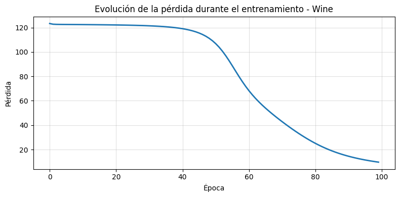

```python
# Gráfico de pérdidas

plt.figure(figsize=(8, 4))
plt.plot(loss_history_wine, linewidth=2)
plt.title("Evolución de la pérdida durante el entrenamiento - Wine")
plt.xlabel("Época")
plt.ylabel("Pérdida")
plt.grid(True, alpha=0.4)
plt.tight_layout()
plt.show()
```

**b) Evaluación del modelo [2 pt.]**

Una vez entrenado el modelo, evaluaremos su rendimiento sobre el conjunto de test. Para esta práctica utilizaremos nuestra propia métrica de evaluación, a la que llamaremos **Penalized Class Accuracy (PCA)**. Esta métrica ha sido diseñada específicamente para esta actividad, por lo que no encontrarás ninguna referencia externa sobre ella.

La métrica se define como:

$$\text{PCA}(y, \hat{y}) = \frac{1}{K} \sum_{k=1}^{K} \frac{\text{TP}_k^2}{\text{TP}_k^2 + \beta \cdot \text{FN}_k^2 + \gamma \cdot \text{FP}_k^2 + \delta \cdot \text{FN}_k \cdot \text{FP}_k}$$

donde:

- $K$ es el número de clases (en este caso $K = 3$),
- $\text{TP}_k$ es el número de muestras de la clase $k$ clasificadas correctamente,
- $\text{FN}_k$ es el número de muestras de la clase $k$ clasificadas como otra clase,
- $\text{FP}_k$ es el número de muestras de otras clases clasificadas incorrectamente como clase $k$,
- $\beta = 2.0$ penaliza los falsos negativos al cuadrado,
- $\gamma = 1.5$ penaliza los falsos positivos al cuadrado,
- $\delta = 0.5$ penaliza la interacción entre falsos negativos y falsos positivos.

Al elevar al cuadrado tanto los aciertos como los errores, la métrica es exigente: un solo error en una clase pequeña tiene un impacto mucho mayor que en el accuracy estándar. Un valor de **1.0** indica clasificación perfecta y el resultado cae rápidamente en cuanto aparecen errores en alguna clase. Tu tarea es:

- Implementar la función `pca_metric` en Python siguiendo estrictamente la fórmula anterior con $\beta = 2.0$, $\gamma = 1.5$ y $\delta = 0.5$.
- Aplicarla sobre las predicciones del conjunto de test.
- Mostrar el resultado

```python
def pca_metric(y_true, y_pred, beta=2.0, gamma=1.5, delta=0.5):
    """
    Penalized Class Accuracy (PCA)
    """
    K = 3 # Número de clases
    pca_sum = 0.0

    for k in range(K):
        # Aciertos y errores por clase
        TP_k = np.sum((y_true == k) & (y_pred == k))
        FN_k = np.sum((y_true == k) & (y_pred != k))
        FP_k = np.sum((y_true != k) & (y_pred == k))

        # Aplicación de la fórmula
        numerador = TP_k**2
        denominador = (TP_k**2) + (beta * FN_k**2) + (gamma * FP_k**2) + (delta * FN_k * FP_k)

        if denominador > 0:
            pca_sum += numerador / denominador

    return pca_sum / K

# Predicciones sobre el conjunto de test
a1_test = sigmoid(np.dot(X_test_wine_n, W1_wine))
a2_test = sigmoid(np.dot(a1_test, W2_wine))
a3_test = softmax(np.dot(a2_test, W3_wine))

y_pred_test = np.argmax(a3_test, axis=1)
y_test_eval = y_test_wine

# Comprobación visual para ver que el modelo ha acertado
print(f"Muestras Test : {y_test_eval[:10]}")
print(f"Predicciones  : {y_pred_test[:10]}\n")
print(f"Aciertos en test: {np.sum(y_test_eval == y_pred_test)} / {len(y_test_eval)}\n")

# Calcular PCA
resultado_pca = pca_metric(y_test_eval, y_pred_test)
print(f"Penalized Class Accuracy (PCA) en Test: {resultado_pca:.4f}")
```

```
Muestras Test : [0 2 0 1 1 0 0 1 1 2]
Predicciones  : [0 2 0 1 1 0 0 1 1 2]

Aciertos en test: 36 / 36

Penalized Class Accuracy (PCA) en Test: 1.0000
```

# 3. Ejercicio 3 - Interpretación de resultados

**Ejercicio 3 [3 pts.]**

Un hospital ha desarrollado un sistema de apoyo al diagnóstico basado en un MLP para clasificar pacientes en 4 categorías según su estado oncológico: **Sano**, **Benigno**, **Maligno** y **Metastásico**. El modelo se ha evaluado sobre un conjunto de test de **400 pacientes** (100 por clase).

A continuación se muestra la matriz de confusión obtenida tras evaluar el modelo sobre el conjunto de test, tanto en valores absolutos como normalizada por clase. Obsérvala con atención antes de responder las preguntas: cada fila representa la clase real del paciente y cada columna la clase predicha por el modelo.

Este ejercicio debe responderse **íntegramente a mano**, explicando el procedimiento y el razonamiento seguido en cada apartado. Los cálculos deben realizarse paso a paso a partir de los valores de la matriz de confusión proporcionada. **No se debe implementar ningún código en ningún apartado.**

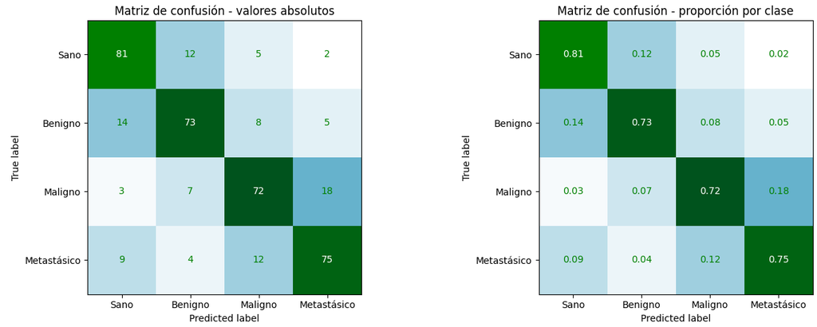

**a) Cálculo manual del accuracy global [0.5 pts.]**

Calcula a mano el **accuracy global** del modelo a partir de los valores de la matriz de confusión. Muestra el procedimiento paso a paso utilizando la siguiente fórmula:

$$\text{Accuracy} = \frac{\sum_{k=1}^{K} \text{TP}_k}{N}$$

donde:

- $\sum_{k=1}^{K} \text{TP}_k$ es la suma de todos los valores de la diagonal principal de la matriz, es decir, el total de muestras clasificadas correctamente,
- $N$ es el número total de muestras del conjunto de test,
- $K$ es el número de clases (en este caso $K = 4$).

**a)** Para calcular el **accuracy global** del modelo se utiliza la suma de los aciertos de todas las clases, es decir, la suma de los valores situados en la **diagonal principal** de la matriz de confusión.

La matriz de confusión tiene **4 clases**:

- **Sano**
- **Benigno**
- **Maligno**
- **Metastásico**

Cada valor de la diagonal principal representa los pacientes que han sido clasificados correctamente dentro de su clase real.

Los aciertos por clase son:

- Pacientes **Sano** clasificados correctamente como **Sano**: $$TP_{\text{Sano}} = 81$$
- Pacientes **Benigno** clasificados correctamente como **Benigno**: $$TP_{\text{Benigno}} = 73$$
- Pacientes **Maligno** clasificados correctamente como **Maligno**: $$TP_{\text{Maligno}} = 72$$
- Pacientes **Metastásico** clasificados correctamente como **Metastásico**: $$TP_{\text{Metastásico}} = 75$$

Por lo tanto, el número total de muestras clasificadas correctamente es: $$\sum_{k=1}^{K} TP_k = TP_{\text{Sano}} + TP_{\text{Benigno}} + TP_{\text{Maligno}} + TP_{\text{Metastásico}}$$

Se substituyen los valores de la matriz: $$\sum_{k=1}^{K} TP_k = 81 + 73 + 72 + 75$$ $$\sum_{k=1}^{K} TP_k = 301$$

El conjunto de test contiene **400 pacientes** en total, ya que hay **100 pacientes por cada una de las 4 clases**: $$N = 100 \cdot 4 = 400$$

La fórmula del **accuracy global** es: $$\text{Accuracy} = \frac{\sum_{k=1}^{K} TP_k}{N}$$

Se substituyen los valores obtenidos: $$\text{Accuracy} = \frac{301}{400} = 0.7525$$

Finalmente, se expresa el resultado en porcentaje: $$0.7525 \cdot 100 = 75.25\%$$

Por lo tanto, el **accuracy global del modelo** es: $$\text{Accuracy} = 0.7525 = 75.25\%$$

Mediante la respuesta obtenida, se observa que el modelo clasifica correctamente **301 de los 400 pacientes** del conjunto de test. Asimismo, en términos porcentuales, el modelo acierta aproximadamente **tres de cada cuatro pacientes**, aunque el accuracy global no permite identificar por sí solo qué clases presentan más errores de clasificación.

**b) Especificidad de las clases Sano y Metastásico [1.5 pts.]**

La **especificidad** de una clase $k$ mide la capacidad del modelo para identificar correctamente los casos que **no** pertenecen a esa clase, es decir, la proporción de negativos reales que el modelo clasifica correctamente como negativos:

$$\text{Especificidad}_k = \frac{\text{TN}_k}{\text{TN}_k + \text{FP}_k}$$

donde:

- $\text{TN}_k$: muestras que no son de la clase $k$ y el modelo predice correctamente que no lo son.
- $\text{FP}_k$: muestras que no son de la clase $k$ pero el modelo predice incorrectamente que sí lo son.

Calcula a mano la especificidad de cada clase y responde los siguientes apartados:

- **`[0.5 pts.]`** Calcula la especificidad de la clase **Sano**. Muestra el procedimiento completo identificando los valores $\text{TN}$ y $\text{FP}$ a partir de la matriz.
- **`[0.5 pts.]`** Calcula la especificidad de la clase **Metastásico**. Muestra el procedimiento completo identificando los valores $\text{TN}$ y $\text{FP}$ a partir de la matriz.
- **`[0.5 pts.]`** Interpreta ambos resultados: ¿qué significa una especificidad baja en el contexto de este diagnóstico oncológico? ¿Cuál de las dos clases consideras más crítica y por qué?

**b)** Tal y como menciona el enunciado, la **especificidad** de una clase (k) mide la proporción de casos que **no pertenecen** a esa clase y que el modelo clasifica correctamente como negativos:

$$\text{Especificidad}_k = \frac{TN_k}{TN_k + FP_k}$$

La matriz de confusión es:

| Clase real \ Clase predicha | **Sano** | **Benigno** | **Maligno** | **Metastásico** |
| --- | --- | --- | --- | --- |
| **Sano** | 81 | 12 | 5 | 2 |
| **Benigno** | 14 | 73 | 8 | 5 |
| **Maligno** | 3 | 7 | 72 | 18 |
| **Metastásico** | 9 | 4 | 12 | 75 |

### 1. Especificidad de la clase **Sano**

Para la clase **Sano**, se consideran negativos reales las clases **Benigno**, **Maligno** y **Metastásico**.

Los **falsos positivos** son los casos que no son **Sano**, pero fueron predichos como **Sano**. Se obtienen de la columna **Sano**, excluyendo la fila **Sano**: $$FP_{\text{Sano}} = 14 + 3 + 9 = 26$$

Los **verdaderos negativos** son los casos que no son **Sano** y tampoco fueron predichos como **Sano**. Se suman las celdas que no pertenecen ni a la fila **Sano** ni a la columna **Sano**: $$TN_{\text{Sano}} = 73 + 8 + 5 + 7 + 72 + 18 + 4 + 12 + 75 = 274$$

Por lo tanto: $$ \text{Especificidad}_{\text{Sano}} = \frac{274}{274 + 26} = \frac{274}{300} = 0.9133 = 91.33\% $$

### 2. Especificidad de la clase **Metastásico**

Para la clase **Metastásico**, se consideran negativos reales las clases **Sano**, **Benigno** y **Maligno**.

Los **falsos positivos** son los casos que no son **Metastásico**, pero fueron predichos como **Metastásico**. Se obtienen de la columna **Metastásico**, excluyendo la fila **Metastásico**:

$$FP_{\text{Metastásico}} = 2 + 5 + 18 = 25$$

Los **verdaderos negativos** son los casos que no son **Metastásico** y tampoco fueron predichos como **Metastásico**. Se suman las celdas que no pertenecen ni a la fila **Metastásico** ni a la columna **Metastásico**: $$TN_{\text{Metastásico}} = 81 + 12 + 5 + 14 + 73 + 8 + 3 + 7 + 72 = 275$$

De manera que: $$ \text{Especificidad}_{\text{Metastásico}} = \frac{275}{275 + 25} = \frac{275}{300} = 0.9167 = 91.67\% $$

### 3. Interpretación de los resultados

Ambos valores de especificidad son altos y muy similares. La especificidad de **Sano** es **91.33%**, lo que significa que el modelo identifica correctamente como **no sanos** al **91.33%** de los pacientes que realmente pertenecen a otras clases. La especificidad de **Metastásico** es **91.67%**, por lo que el modelo identifica correctamente como **no metastásicos** al **91.67%** de los pacientes que realmente no tienen esa condición.

Una **especificidad baja** implicaría muchos **falsos positivos** para una clase. En este diagnóstico oncológico, esto puede tener consecuencias importantes. Si la especificidad de **Sano** fuera baja, pacientes con alguna patología podrían ser clasificados erróneamente como sanos, retrasando el diagnóstico y el tratamiento. Si la especificidad de **Metastásico** fuera baja, pacientes no metastásicos podrían ser clasificados como metastásicos, generando ansiedad, pruebas adicionales o tratamientos innecesarios.

Aunque ambas clases son importantes, se considera más crítica la clase **Sano**, porque clasificar como sano a un paciente que realmente no lo está puede retrasar la detección de una enfermedad oncológica, demorar el inicio del tratamiento adecuado y afectar negativamente a su pronóstico.

**c) Cálculo manual de la salida de una neurona [1 pt.]**

Considera una neurona con **3 entradas**, un **sesgo** (*bias*) y la función de activación **ReLU**. La neurona recibe los siguientes valores:

| Entrada | Valor | Peso |
| --- | --- | --- |
| $x_1$ | 0.5 | 1.2 |
| $x_2$ | -1.0 | -0.8 |
| $x_3$ | 2.0 | 0.4 |
| Sesgo | 1 | -1.5 |

La función de activación ReLU se define como:

$$\phi(z) = \max(0, z)$$

El esquema de la neurona es el siguiente:

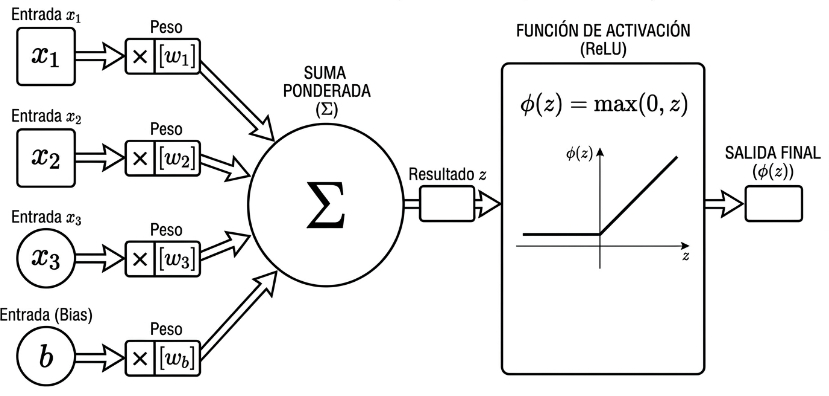

Calcula *a mano* la salida final de esta neurona, es decir, el valor $\phi(z)$ que sale tras aplicar ReLU. Muestra el procedimiento completo: primero calcula la combinación lineal $z = \sum_{i} w_i x_i + b$ mostrando cada término por separado, y después aplica la función de activación sobre el resultado obtenido. **No se debe implementar ningún código.**

**c)** Para obtener la salida final de la neurona, primero se calcula la **combinación lineal** ($z$), sumando el producto de cada entrada por su peso y añadiendo el término de sesgo.

La expresión general es:

$$z = \sum_i w_i x_i + b$$

Con los valores del enunciado:

$$x_1 = 0.5, \quad w_1 = 1.2$$ $$x_2 = -1.0, \quad w_2 = -0.8$$ $$x_3 = 2.0, \quad w_3 = 0.4$$ $$x_b = 1, \quad w_b = -1.5$$

Se calcula cada término por separado:

$$w_1x_1 = 1.2 \cdot 0.5 = 0.6$$ $$w_2x_2 = (-0.8) \cdot (-1.0) = 0.8$$ $$w_3x_3 = 0.4 \cdot 2.0 = 0.8$$ $$w_bx_b = (-1.5) \cdot 1 = -1.5$$

Ahora se sustituye en la combinación lineal: $$z = 0.6 + 0.8 + 0.8 + (-1.5)$$ $$z = 2.2 - 1.5$$ $$z = 0.7$$

Una vez obtenido ($z$), se aplica la función de activación **ReLU**, definida como: $$\phi(z) = \max(0, z)$$

Se sustituye el valor calculado: $$\phi(0.7) = \max(0, 0.7)$$

Como ($0.7 > 0$), la función **ReLU** devuelve el mismo valor: $$\phi(0.7) = 0.7$$

Por lo tanto, la salida final de la neurona es: $$\phi(z) = 0.7$$

# Bibliografía

Project Jupyter. (s. f.). *Jupyter Notebook* [Software]. https://jupyter.org/

Python Software Foundation. (s. f.). *Python language reference* [Software]. https://www.python.org/

Moreno i Ribas, A., Torra i Reventós, V., & Masip i Rodó, D. (2013). *Aprendizaje computacional* (módulo 0). Fundació Universitat Oberta de Catalunya.

Torra i Reventós, V., & Masip i Rodó, D. (s. f.). *Aprendizaje* (módulo 1). Fundació Universitat Oberta de Catalunya.

Moreno i Ribas, A. (s. f.). *Agentes y sistemas multiagente* (módulo 2). Fundació Universitat Oberta de Catalunya.

Castro García, J. F. (2006). *Fundamentos para la implementación de red neuronal perceptrón multicapa mediante software* [Tesis de grado, Universidad de San Carlos de Guatemala]. https://biblio.ingenieria.usac.edu.gt/tesis/08_0155_EO.pdf

Molina Arias, M. (2025). Redes neuronales artificiales: Fundamentos y aplicaciones. *Evidencias en Pediatría, 21*, 25. https://evidenciasenpediatria.es/articulo/8518/redes-neuronales-artificiales-fundamentos-y-aplicaciones

Ramos, J. M. S. (s. f.). *Introducción a las redes neuronales artificiales*. https://files01.core.ac.uk/download/580454679.pdf

Torres, C. J. (s. f.). *Redes neuronales y perceptrón multicapa*. https://cjtorresj.quarto.pub/aaycd/2-07-intro-redes-neuro.html

Universidad Carlos III de Madrid. (s. f.). *Fundamentos de las redes neuronales: Parte I, L6*. https://ocw.uc3m.es/pluginfile.php/143/mod_page/content/24/Fundamentos%20de%20las%20Redes%20Neuronales.%20Parte%20I%20L6.pdf?time=1632131411627

Kim, G., & Bak, Y. (2025). Forward and backpropagation-based artificial neural network modeling method for power conversion system. *Electronics, 14*(23), 4718. https://doi.org/10.3390/electronics14234718

D2L.ai. (s. f.). *Forward propagation, backward propagation, and computational graphs*. https://d2l.ai/chapter_multilayer-perceptrons/backprop.html

Rainio, O., Teuho, J., & Klén, R. (2024). Evaluation metrics and statistical tests for machine learning. *Scientific Reports, 14*, 6086. https://doi.org/10.1038/s41598-024-56706-x

Harris, C. R., Millman, K. J., van der Walt, S. J., Gommers, R., Virtanen, P., Cournapeau, D., Wieser, E., Taylor, J., Berg, S., Smith, N. J., Kern, R., Picus, M., Hoyer, S., van Kerkwijk, M. H., Brett, M., Haldane, A., del Río, J. F., Wiebe, M., Peterson, P., Gérard-Marchant, P., Sheppard, K., Reddy, T., Weckesser, W., Abbasi, H., Gohlke, C., & Oliphant, T. E. (2020). Array programming with NumPy. *Nature, 585*, 357–362. https://doi.org/10.1038/s41586-020-2649-2

The pandas development team. (s. f.). *User guide*. *Pandas documentation*. https://pandas.pydata.org/docs/user_guide/index.html

Hunter, J. D. (2007). Matplotlib: A 2D graphics environment. *Computing in Science & Engineering, 9*(3), 90–95. https://doi.org/10.1109/MCSE.2007.55

Pedregosa, F., Varoquaux, G., Gramfort, A., Michel, V., Thirion, B., Grisel, O., Blondel, M., Prettenhofer, P., Weiss, R., Dubourg, V., VanderPlas, J., Passos, A., Cournapeau, D., Brucher, M., Perrot, M., & Duchesnay, É. (2011). Scikit-learn: Machine learning in Python. *Journal of Machine Learning Research, 12*, 2825–2830. http://jmlr.org/papers/v12/pedregosa11a.html

OpenAI. (2026). *ChatGPT* (versión GPT-5.5) [Modelo de lenguaje grande]. https://chatgpt.com/

# Citación de la IA generativa utilizada

Durante la elaboración de esta PEC se ha hecho uso de la herramienta ChatGPT (versión GPT-5.5) desarrollada por OpenAI, como apoyo en la redacción y revisión de algunos apartados teóricos.

Se ha supervisado y editado todo el contenido de forma exhaustiva, garantizando que el resultado final sea original, riguroso y coherente con los criterios académicos de la UOC.